# Finallll

682 rows × 22 columns

### Get iPhone X weighted positive, negative words top 500

```python
iX_complete2 = iX_complete2.sort_values(by = ['Sentiment'],ascending=False)

iX_complete2 = iX_complete2.drop(columns=['level_0', 'index'])
iX_complete2 = iX_complete2.reset_index()

get_BOW_weight(iX_complete2)
```

```
Postive:

('galaxy', 0.23807849460663694)
('oneplus', 0.2220451353046929)
('now', 0.2129195402912901)
('iphone', 0.20630183351079137)
('you', 0.20140185166831492)
('has', 0.18659686648344997)
('new', 0.16809859242495725)
('is the', 0.1625784273952129)
('screen', 0.1596438341452472)
('more', 0.1591654229809387)
('your', 0.13937893642395804)
('features', 0.13676292084421074)
('on', 0.13164274054428834)
('only', 0.12761787082302453)
('are', 0.12211310204579824)
('in the', 0.11976853319521094)
('twitter', 0.11419015176939644)
('buy', 0.11390196694684247)
('which', 0.11382907110794832)
('like', 0.10976418385463224)
('galaxy s8', 0.10559905586107189)
('been', 0.10483217331331447)
('up', 0.10459434945950752)
('price', 0.10394012440656554)
('charging', 0.10360180211594369)
('front', 0.1011989063814115)
('while', 0.10076670269256878)
('pixel xl', 0.10048035478048259)
('https', 0.10034741198025106)
('you can', 0.09841546048245778)
('edge', 0.09653795639410276)
('the notch', 0.09449482538386632)
('5t', 0.09323519184493383)
('oneplus 5t', 0.09307903569517532)
('than', 0.09299069586435368)
('do', 0.09273119863766703)
('s8 or', 0.0912593994974929)
('will', 0.0905817295448981)
```

[output cut: 950 more lines]

```
('with that', -0.03322450675816058)
('and winner', -0.0331828790792921)
('html tags', -0.0331828790792921)
('is html', -0.0331828790792921)
('tags pinoy', -0.0331828790792921)
('the winner', -0.0331828790792921)
('any other', -0.03309563138441572)
('84', -0.03308138271275018)
('directly', -0.0329400452482699)
('september', -0.03286172847057618)
('as easy', -0.032856200035602086)
('then you', -0.03284579647973185)
('burn in', -0.032840714596482086)
('from devices', -0.032823543806697296)
('lags', -0.03267979318049565)
```

```python
#iX_complete2.to_csv('iX_complete.csv')
```

# Feature Sentiment Extraction

```python
# socialT['Published Date (GMT-04:00) New York'] = pd.to_datetime(socialT['Published Date (GMT-04:00) New York'])
```

```python
socialT.info()
```

```
<class 'pandas.core.frame.DataFrame'>
RangeIndex: 380296 entries, 0 to 380295
Data columns (total 19 columns):
index                                     380296 non-null int64
Sound Bite Text                           380296 non-null object
Title                                     380296 non-null object
Post Type                                 380296 non-null object
Published Date (GMT-04:00) New York       380296 non-null datetime64[ns]
Source Type                               380296 non-null object
No. of Followers/Daily Unique Visitors    380296 non-null float64
Author Gender                             380296 non-null object
Positive Objects                          83010 non-null object
Negative Objects                          37556 non-null object
Author Location - Country 1               380296 non-null object
lower_text                                380296 non-null object
clear_text                                380296 non-null object
clear_text_str                            380296 non-null object
blob_sentiment                            380296 non-null float64
clear_text_ngram2                         380296 non-null object
Sentiment                                 380296 non-null object
S8                                        380296 non-null float64
iPhone                                    380296 non-null float64
dtypes: datetime64[ns](1), float64(4), int64(1), object(13)
memory usage: 55.1+ MB
```

```python
def get_feature_sentiment(dataframe, feature, start_time=None, end_time=None):

    if start_time != None:
        dataframe = dataframe[dataframe['Published Date (GMT-04:00) New York'] >= pd.to_datetime(start_time)]
        dataframe = dataframe[dataframe['Published Date (GMT-04:00) New York'] < pd.to_datetime(end_time)]

    dff = dataframe[dataframe['clear_text_ngram2'].apply(lambda x: ' '.join(x)).str.contains(feature) == True]['blob_sentiment']

    overall_mean = dff.mean()
    positive_mean = dff[dff > 0].mean()
    negative_mean = dff[dff < 0].mean()

    feature_dict = {
        'feature': feature,
        'overall_mean': overall_mean,
        'positive_mean': positive_mean,
        'negative_mean': negative_mean
    }


    feature_df = pd.DataFrame(feature_dict, index=[feature])


    print("Mean: " + str(overall_mean))

    print("Positive: " + str(dff[dff > 0].mean()))

    print("Negative: " + str(dff[dff < 0].mean()))

    return feature_df
```

```python
def get_feature_df(dataframe, feature_list, start_time=None, end_time=None):
    df = get_feature_sentiment(dataframe, feature_list[0], start_time=start_time, end_time=end_time)

    for f in feature_list:
        df = df.append(get_feature_sentiment(dataframe, f, start_time=start_time, end_time=end_time))
    df.reset_index()
#     df.drop([0], inplace=True)

    return df.iloc[1:]
```

After extract the most important features, we now want to know the text sentiment about these features. We use the model we trained above to find out the overall mean scores, positive mean scores and negative mean scores. From these data, we can know the average response from the commenters for these product. The following are the steps of finding sentiments.

# S8 feature

```python
infinity_sentiment = get_feature_sentiment(s8DF, 'infinity display')
```

```
Mean: 0.183481815653387
Positive: 0.20028927611962805
Negative: -0.06483994231319891
```

```python
s8_alltime_sentiment = infinity_sentiment.copy()
```

```python
snapdragon_sentiment = get_feature_sentiment(s8DF, 'snapdragon')
```

```
Mean: 0.14975169296453575
Positive: 0.1682374815197779
Negative: -0.06740538840065208
```

```python
s8_home_button_sentiment = get_feature_sentiment(s8DF, 'home button')
```

```
Mean: 0.12383400635011513
Positive: 0.1478932790737921
Negative: -0.0758903863308982
```

```python
s8_wire_charging_sentiment = get_feature_sentiment(s8DF, 'wireless charging')
```

```
Mean: 0.174295639023255
Positive: 0.19632766737771967
Negative: -0.07788523054305452
```

```python
s8_fingerprint_sentiment = get_feature_sentiment(s8DF, 'fingerprint sensor')
```

```
Mean: 0.10937864254120275
Positive: 0.15138848140927766
Negative: -0.1713255219884512
```

```python
s8_iris_sentiment = get_feature_sentiment(s8DF, 'iris')
```

```
Mean: 0.14390777659891585
Positive: 0.17424169603504763
Negative: -0.13916804937282748
```

```python
s8_facial_sentiment = get_feature_sentiment(s8DF, 'facial recognition')
```

```
Mean: 0.12298982941497327
Positive: 0.1412384490863276
Negative: -0.06706302831846146
```

```python
s8_battery_sentiment = get_feature_sentiment(s8DF, 'battery life')
```

```
Mean: 0.1961204285634931
Positive: 0.20732685459104663
Negative: -0.07592513273177914
```

```python
s8_gear_vr_sentiment = get_feature_sentiment(s8DF, 'gear vr')
```

```
Mean: 0.17373758722294366
Positive: 0.1955903187815918
Negative: -0.12403802654752753
```

```python
s8_price_sentiment = get_feature_sentiment(s8DF, 'price|cost|expansive|pricy|pricey')
```

```
Mean: 0.16416339353881948
Positive: 0.19354185645859828
Negative: -0.08605853665079417
```

```python
s8_alltime_sentiment = s8_alltime_sentiment.append(snapdragon_sentiment)
s8_alltime_sentiment = s8_alltime_sentiment.append(s8_home_button_sentiment)
s8_alltime_sentiment = s8_alltime_sentiment.append(s8_wire_charging_sentiment)
s8_alltime_sentiment = s8_alltime_sentiment.append(s8_fingerprint_sentiment)
s8_alltime_sentiment = s8_alltime_sentiment.append(s8_iris_sentiment)
s8_alltime_sentiment = s8_alltime_sentiment.append(s8_facial_sentiment)
s8_alltime_sentiment = s8_alltime_sentiment.append(s8_battery_sentiment)
s8_alltime_sentiment = s8_alltime_sentiment.append(s8_gear_vr_sentiment)
```

```python
s8_alltime_sentiment
```

|  | feature | overall_mean | positive_mean | negative_mean |
| --- | --- | --- | --- | --- |
| infinity display | infinity display | 0.183482 | 0.200289 | -0.064840 |
| snapdragon | snapdragon | 0.149752 | 0.168237 | -0.067405 |
| home button | home button | 0.123834 | 0.147893 | -0.075890 |
| wireless charging | wireless charging | 0.174296 | 0.196328 | -0.077885 |
| fingerprint sensor | fingerprint sensor | 0.109379 | 0.151388 | -0.171326 |
| iris | iris | 0.143908 | 0.174242 | -0.139168 |
| facial recognition | facial recognition | 0.122990 | 0.141238 | -0.067063 |
| battery life | battery life | 0.196120 | 0.207327 | -0.075925 |
| gear vr | gear vr | 0.173738 | 0.195590 | -0.124038 |
| price\|cost\|expansive\|pricy\|pricey | price\|cost\|expansive\|pricy\|pricey | 0.164163 | 0.193542 | -0.086059 |

The table above presents the sentiment score for each features of Samsung s8.

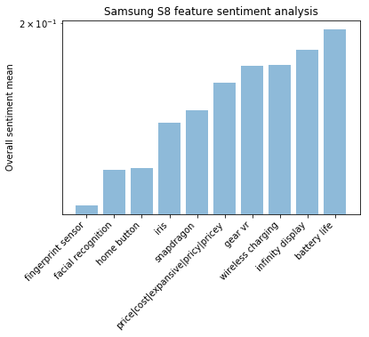

```python
s8_mean = s8_alltime_sentiment.sort_values('overall_mean')

x = s8_mean['feature']
y = s8_mean['overall_mean']
plt.bar(x, y, align='center', alpha=0.5)
plt.setp(plt.gca().get_xticklabels(), rotation=45, horizontalalignment='right')
plt.ylabel('Overall sentiment mean')
plt.title('Samsung S8 feature sentiment analysis')
plt.yscale('log')

plt.show()
```

Using the bar chart to show the overall ranking of most like/dislike features.

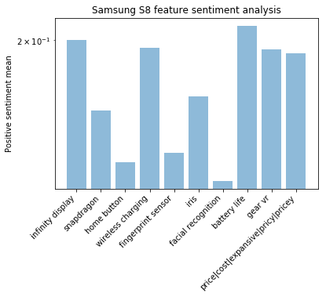

```python
# s8_positive = s8_alltime_sentiment.sort_values('positive_mean')
s8_positive = s8_alltime_sentiment
x = s8_positive['feature']
y = s8_positive['positive_mean']
plt.bar(x, y, align='center', alpha=0.5)
plt.setp(plt.gca().get_xticklabels(), rotation=45, horizontalalignment='right')
plt.ylabel('Positive sentiment mean')
plt.title('Samsung S8 feature sentiment analysis')
plt.yscale('log')

plt.show()
```

Using the bar chart to show the positive ranking of most like features.  
Top 3 Positive features are : Battery life, infinity display, wireless charging.

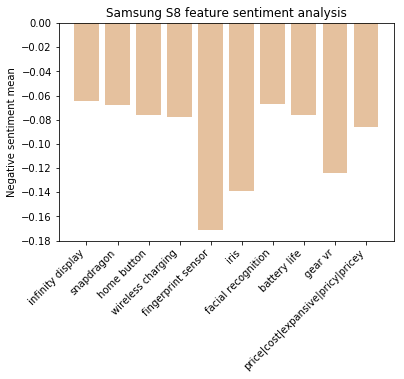

```python
# s8_neg = s8_alltime_sentiment.sort_values('negative_mean', ascending=False)
s8_neg = s8_alltime_sentiment
x = s8_neg['feature']
y = s8_neg['negative_mean']
plt.bar(x, y, align='center', alpha=0.5, color='#CD853F')
plt.setp(plt.gca().get_xticklabels(), rotation=45, horizontalalignment='right')
plt.ylabel('Negative sentiment mean')
plt.title('Samsung S8 feature sentiment analysis')
# plt.yscale('log')

plt.show()
```

Using the bar chart to show the negative ranking of most dislike features.  
Top 3 Negaive features are : fingerprint sensor, iris and gear vr.

# IPhone 8 Feature

```python
i8_df = iPDF[iPDF['i8'] == 1]
```

```python
i8_oled_sentiment = get_feature_sentiment(i8_df, 'oled display')
```

```
Mean: 0.1082654205750223
Positive: 0.13221141805151895
Negative: -0.06125203989907394
```

```python
i8_alltime_sentiment = i8_oled_sentiment.copy()
```

```python
i8_wire_charging_sentiment = get_feature_sentiment(i8_df, 'wireless charging')
```

```
Mean: 0.13806058466427104
Positive: 0.16474331753996477
Negative: -0.09326075264380813
```

```python
i8_ar_sentiment = get_feature_sentiment(i8_df, 'augmented reality')
```

```
Mean: 0.12991031803183814
Positive: 0.15764962475697167
Negative: -0.08621283766154153
```

```python
i8_a11_sentiment = get_feature_sentiment(i8_df, 'bionic')
```

```
Mean: 0.15066217553143665
Positive: 0.16798291553680034
Negative: -0.06880254727273755
```

```python
i8_dual_camera_sentiment = get_feature_sentiment(i8_df, 'dual camera')
```

```
Mean: 0.11786515323533256
Positive: 0.14350638940018887
Negative: -0.07920691614389677
```

```python
i8_battery_sentiment = get_feature_sentiment(i8_df, 'battery life')
```

```
Mean: 0.14397066921786011
Positive: 0.1766822903776001
Negative: -0.10926066794242693
```

```python
i8_facial_sentiment = get_feature_sentiment(i8_df, 'facial recognition')
```

```
Mean: 0.10167958350146171
Positive: 0.12593000482131672
Negative: -0.08353775212146322
```

```python
i8_fingerprint_sentiment = get_feature_sentiment(i8_df, 'fingerprint sensor')
```

```
Mean: 0.08872997221217224
Positive: 0.11883329412483515
Negative: -0.07848130086541102
```

```python
i8_portrait_mode_sentiment = get_feature_sentiment(i8_df, 'portrait mode')
```

```
Mean: 0.17698338470681638
Positive: 0.22286711588616767
Negative: -0.18253569533044722
```

```python
i8_price_sentiment = get_feature_sentiment(i8_df, 'price|cost|expansive|pricy|pricey')
```

```
Mean: 0.13096050507146403
Positive: 0.17862584064393663
Negative: -0.10564428001151045
```

```python
i8_alltime_sentiment = i8_alltime_sentiment.append(i8_wire_charging_sentiment)
i8_alltime_sentiment = i8_alltime_sentiment.append(i8_ar_sentiment)
i8_alltime_sentiment = i8_alltime_sentiment.append(i8_a11_sentiment)
i8_alltime_sentiment = i8_alltime_sentiment.append(i8_dual_camera_sentiment)
i8_alltime_sentiment = i8_alltime_sentiment.append(i8_battery_sentiment)
i8_alltime_sentiment = i8_alltime_sentiment.append(i8_facial_sentiment)
i8_alltime_sentiment = i8_alltime_sentiment.append(i8_fingerprint_sentiment)
i8_alltime_sentiment = i8_alltime_sentiment.append(i8_portrait_mode_sentiment)
i8_alltime_sentiment = i8_alltime_sentiment.append(i8_price_sentiment)
```

```python
i8_alltime_sentiment
```

|  | feature | overall_mean | positive_mean | negative_mean |
| --- | --- | --- | --- | --- |
| oled display | oled display | 0.108265 | 0.132211 | -0.061252 |
| wireless charging | wireless charging | 0.138061 | 0.164743 | -0.093261 |
| augmented reality | augmented reality | 0.129910 | 0.157650 | -0.086213 |
| bionic | bionic | 0.150662 | 0.167983 | -0.068803 |
| dual camera | dual camera | 0.117865 | 0.143506 | -0.079207 |
| battery life | battery life | 0.143971 | 0.176682 | -0.109261 |
| facial recognition | facial recognition | 0.101680 | 0.125930 | -0.083538 |
| fingerprint sensor | fingerprint sensor | 0.088730 | 0.118833 | -0.078481 |
| portrait mode | portrait mode | 0.176983 | 0.222867 | -0.182536 |
| price\|cost\|expansive\|pricy\|pricey | price\|cost\|expansive\|pricy\|pricey | 0.130961 | 0.178626 | -0.105644 |

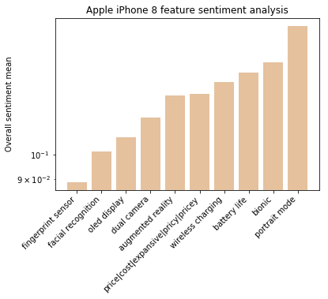

```python
i8_mean = i8_alltime_sentiment.sort_values('overall_mean')

x = i8_mean['feature']
y = i8_mean['overall_mean']
plt.bar(x, y, align='center', alpha=0.5, color='#CD853F')
plt.setp(plt.gca().get_xticklabels(), rotation=45, horizontalalignment='right')
plt.ylabel('Overall sentiment mean')
plt.title('Apple iPhone 8 feature sentiment analysis')
plt.yscale('log')

plt.show()
```

Using the bar chart to present the overall ranking of features sentiment. Top 3 features are portrait mode, bionic and battery life.

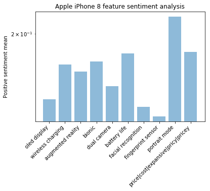

```python
#i8_pos = i8_alltime_sentiment.sort_values('positive_mean')
i8_pos = i8_alltime_sentiment
x = i8_pos['feature']
y = i8_pos['positive_mean']
plt.bar(x, y, align='center', alpha=0.5)
plt.setp(plt.gca().get_xticklabels(), rotation=45, horizontalalignment='right')
plt.ylabel('Positive sentiment mean')
plt.title('Apple iPhone 8 feature sentiment analysis')
plt.yscale('log')

plt.show()
```

Using the bar chart to show the positive ranking of most like features.  
Top 3 Positive features are : portrait mode, price, battery life.

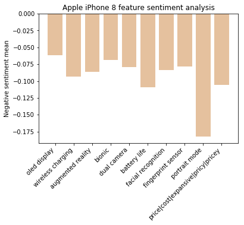

```python
#i8_neg = i8_alltime_sentiment.sort_values('negative_mean', ascending=False)
i8_neg = i8_alltime_sentiment
x = i8_neg['feature']
y = i8_neg['negative_mean']
plt.bar(x, y, align='center', alpha=0.5, color='#CD853F')
plt.setp(plt.gca().get_xticklabels(), rotation=45, horizontalalignment='right')
plt.ylabel('Negative sentiment mean')
plt.title('Apple iPhone 8 feature sentiment analysis')
# plt.yscale('log')

plt.show()
```

Using the bar chart to show the negative ranking of most dislike features.  
Top 3 Negative features are : portrait mode, battery life and price.

# IPhone X Feature

```python
iX_df = iPDF[iPDF['iX'] == 1]
```

```python
iX_wire_charging_sentiment = get_feature_sentiment(iX_df, 'wireless charging')
```

```
Mean: 0.14477236777957866
Positive: 0.161766040043546
Negative: -0.08429221461202031
```

```python
iX_alltime_sentiment = iX_wire_charging_sentiment.copy()
```

```python
iX_face_id_sentiment = get_feature_sentiment(iX_df, 'face id')
```

```
Mean: 0.1339620287578133
Positive: 0.1597665064068964
Negative: -0.07047495191526844
```

```python
iX_a11_sentiment = get_feature_sentiment(iX_df, 'bionic')
```

```
Mean: 0.14853052871802339
Positive: 0.16386056038316296
Negative: -0.06319034275552766
```

```python
iX_home_button_sentiment = get_feature_sentiment(iX_df, 'home button')
```

```
Mean: 0.13411057297359605
Positive: 0.149368712793722
Negative: -0.0736910646140634
```

```python
iX_ar_sentiment = get_feature_sentiment(iX_df, 'augmented reality')
```

```
Mean: 0.12061276688982592
Positive: 0.15185316813453859
Negative: -0.10995302956144522
```

```python
iX_battery_sentiment = get_feature_sentiment(iX_df, 'battery life')
```

```
Mean: 0.13353555293827873
Positive: 0.15326618388392607
Negative: -0.07810203481076172
```

```python
iX_dual_camera_sentiment = get_feature_sentiment(iX_df, 'dual camera')
```

```
Mean: 0.15197968686550142
Positive: 0.1629229873447684
Negative: -0.046451225315268636
```

```python
iX_facial_sentiment = get_feature_sentiment(iX_df, 'facial recognition')
```

```
Mean: 0.11845193415747
Positive: 0.13483114357589585
Negative: -0.056155925295299246
```

```python
iX_glassback_sentiment = get_feature_sentiment(iX_df, 'glass back')
```

```
Mean: 0.12836591792342314
Positive: 0.13944735480455883
Negative: -0.0533812889130544
```

```python
iX_charging_pad_sentiment = get_feature_sentiment(iX_df, 'charging pad')
```

```
Mean: 0.14777771300463136
Positive: 0.16496970724289925
Negative: -0.09897469441668583
```

```python
iX_price_sentiment = get_feature_sentiment(iX_df, 'price|cost|expansive|pricy|pricey')
```

```
Mean: 0.1251747669369225
Positive: 0.1540167305404533
Negative: -0.08435672315843248
```

```python
iX_alltime_sentiment = iX_alltime_sentiment.append(iX_face_id_sentiment)
iX_alltime_sentiment = iX_alltime_sentiment.append(iX_a11_sentiment)
iX_alltime_sentiment = iX_alltime_sentiment.append(iX_home_button_sentiment)
iX_alltime_sentiment = iX_alltime_sentiment.append(iX_ar_sentiment)
iX_alltime_sentiment = iX_alltime_sentiment.append(iX_dual_camera_sentiment)
iX_alltime_sentiment = iX_alltime_sentiment.append(iX_glassback_sentiment)
iX_alltime_sentiment = iX_alltime_sentiment.append(iX_charging_pad_sentiment)
iX_alltime_sentiment = iX_alltime_sentiment.append(iX_price_sentiment)
iX_alltime_sentiment
```

|  | feature | overall_mean | positive_mean | negative_mean |
| --- | --- | --- | --- | --- |
| wireless charging | wireless charging | 0.144772 | 0.161766 | -0.084292 |
| face id | face id | 0.133962 | 0.159767 | -0.070475 |
| bionic | bionic | 0.148531 | 0.163861 | -0.063190 |
| home button | home button | 0.134111 | 0.149369 | -0.073691 |
| augmented reality | augmented reality | 0.120613 | 0.151853 | -0.109953 |
| dual camera | dual camera | 0.151980 | 0.162923 | -0.046451 |
| glass back | glass back | 0.128366 | 0.139447 | -0.053381 |
| charging pad | charging pad | 0.147778 | 0.164970 | -0.098975 |
| price\|cost\|expansive\|pricy\|pricey | price\|cost\|expansive\|pricy\|pricey | 0.125175 | 0.154017 | -0.084357 |

```python
#ix_mean = iX_alltime_sentiment.sort_values('overall_mean')
ix_mean = iX_alltime_sentiment

x = ix_mean['feature']
y = ix_mean['overall_mean']
plt.bar(x, y, align='center', alpha=0.5)
plt.setp(plt.gca().get_xticklabels(), rotation=45, horizontalalignment='right')
plt.ylabel('Overall sentiment mean')
plt.title('Apple iPhone X feature sentiment analysis')
plt.yscale('log')

plt.show()
```

[output not shown]

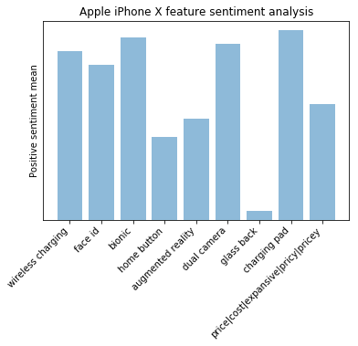

```python
#ix_pro = iX_alltime_sentiment.sort_values('positive_mean')
ix_pro = iX_alltime_sentiment
x = ix_pro['feature']
y = ix_pro['positive_mean']
plt.bar(x, y, align='center', alpha=0.5)
plt.setp(plt.gca().get_xticklabels(), rotation=45, horizontalalignment='right')
plt.ylabel('Positive sentiment mean')
plt.title('Apple iPhone X feature sentiment analysis')
plt.yscale('log')

plt.show()
```

Using the bar chart to show the positive ranking of most like features.  
Top 3 Positive features are : charging pad, bonic, dual camera.

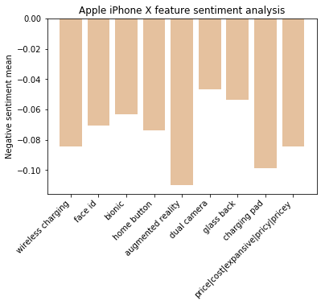

```python
# ix_neg = iX_alltime_sentiment.sort_values('negative_mean', ascending=False)
ix_neg = iX_alltime_sentiment

x = ix_neg['feature']
y = ix_neg['negative_mean']
plt.bar(x, y, align='center', alpha=0.5, color='#CD853F')
plt.setp(plt.gca().get_xticklabels(), rotation=45, horizontalalignment='right')
plt.ylabel('Negative sentiment mean')
plt.title('Apple iPhone X feature sentiment analysis')
# plt.yscale('log')

plt.show()
```

Using the bar chart to show the negative ranking of most like features.  
Top 3 Negative features are : augmented reality, charging pad, price.

# Before and After launch comparison

In order to understand how people reacted before and after product launch, we use a month before and after 2017/3/29 as the time frame to do the analysis.

```python
s8DF['Published Date (GMT-04:00) New York'] = pd.to_datetime(s8DF['Published Date (GMT-04:00) New York'])
```

```python
s8_b4_launch = get_feature_df(s8DF,
                              ['infinity display',
                               'snapdragon',
                               'home button',
                               'wireless charging',
                               'fingerprint sensor',
                               'iris','facial recognition',
                               'battery life',
                               'gear vr','price|cost|expansive|pricy|pricey'],
                              '20170301', '20170329')
```

```
Mean: 0.09971490420522704
Positive: 0.11479053220183448
Negative: -0.034642728303442595
Mean: 0.09971490420522704
Positive: 0.11479053220183448
Negative: -0.034642728303442595
Mean: 0.12392471662937345
Positive: 0.1460709795599144
Negative: -0.07728842456607797
Mean: 0.10406582645427948
Positive: 0.12058009483879051
Negative: -0.06724943067666346
Mean: 0.12363419024123688
Positive: 0.1324606447204327
Negative: -0.03167311207311206
Mean: -0.03573741581646951
Positive: 0.11124098250246722
Negative: -0.4289121360169605
Mean: 0.10952830467146735
Positive: 0.12242580767380609
Negative: -0.04073001793538817
Mean: 0.0920097359252679
Positive: 0.11840994926984345
Negative: -0.06184075926054535
Mean: 0.14477902078789787
Positive: 0.15624630664313094
Negative: -0.04323593073593074
Mean: 0.149299360443563
Positive: 0.1512023885796437
Negative: -0.008828671328671326
Mean: 0.13477972901611918
Positive: 0.1648303105448557
Negative: -0.0849823079141779
```

```python
s8_b4_launch
```

|  | feature | overall_mean | positive_mean | negative_mean |
| --- | --- | --- | --- | --- |
| infinity display | infinity display | 0.099715 | 0.114791 | -0.034643 |
| snapdragon | snapdragon | 0.123925 | 0.146071 | -0.077288 |
| home button | home button | 0.104066 | 0.120580 | -0.067249 |
| wireless charging | wireless charging | 0.123634 | 0.132461 | -0.031673 |
| fingerprint sensor | fingerprint sensor | -0.035737 | 0.111241 | -0.428912 |
| iris | iris | 0.109528 | 0.122426 | -0.040730 |
| facial recognition | facial recognition | 0.092010 | 0.118410 | -0.061841 |
| battery life | battery life | 0.144779 | 0.156246 | -0.043236 |
| gear vr | gear vr | 0.149299 | 0.151202 | -0.008829 |
| price\|cost\|expansive\|pricy\|pricey | price\|cost\|expansive\|pricy\|pricey | 0.134780 | 0.164830 | -0.084982 |

```python
s8_after_launch = get_feature_df(s8DF,
                              ['infinity display',
                               'snapdragon',
                               'home button',
                               'wireless charging',
                               'fingerprint sensor',
                               'iris','facial recognition',
                               'battery life',
                               'gear vr','price|cost|expansive|pricy|pricey'],
                              '20170329', '20170430')
```

```
Mean: 0.17503445957327018
Positive: 0.1900332821366295
Negative: -0.06828266272936129
Mean: 0.17503445957327018
Positive: 0.1900332821366295
Negative: -0.06828266272936129
Mean: 0.15532136734417334
Positive: 0.17089133274144344
Negative: -0.07148032576102512
Mean: 0.1260937336756988
Positive: 0.1497528969321909
Negative: -0.08410719757080101
Mean: 0.16931351457301128
Positive: 0.18822537654269145
Negative: -0.0820809389829195
Mean: 0.11730721545396026
Positive: 0.15244847081479762
Negative: -0.1035690309130627
Mean: 0.1580931744161106
Positive: 0.17081616282467843
Negative: -0.07389666756656811
Mean: 0.1256028965094414
Positive: 0.1425520731409098
Negative: -0.0739435759001095
Mean: 0.1899774023795329
Positive: 0.1976166639318021
Negative: -0.08495972518192486
Mean: 0.1731913754433883
Positive: 0.19358446476225716
Negative: -0.11386698170788839
Mean: 0.15960255469342788
Positive: 0.18432009185293027
Negative: -0.08352740768670544
```

```python
s8_after_launch
```

|  | feature | overall_mean | positive_mean | negative_mean |
| --- | --- | --- | --- | --- |
| infinity display | infinity display | 0.175034 | 0.190033 | -0.068283 |
| snapdragon | snapdragon | 0.155321 | 0.170891 | -0.071480 |
| home button | home button | 0.126094 | 0.149753 | -0.084107 |
| wireless charging | wireless charging | 0.169314 | 0.188225 | -0.082081 |
| fingerprint sensor | fingerprint sensor | 0.117307 | 0.152448 | -0.103569 |
| iris | iris | 0.158093 | 0.170816 | -0.073897 |
| facial recognition | facial recognition | 0.125603 | 0.142552 | -0.073944 |
| battery life | battery life | 0.189977 | 0.197617 | -0.084960 |
| gear vr | gear vr | 0.173191 | 0.193584 | -0.113867 |
| price\|cost\|expansive\|pricy\|pricey | price\|cost\|expansive\|pricy\|pricey | 0.159603 | 0.184320 | -0.083527 |

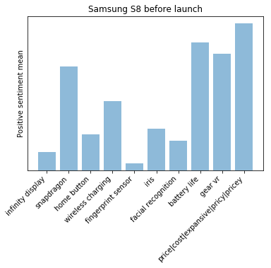

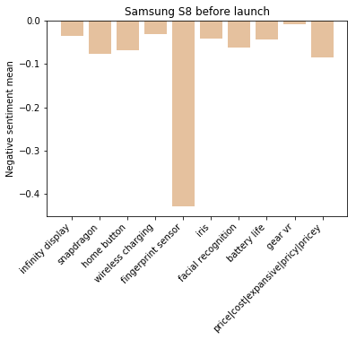

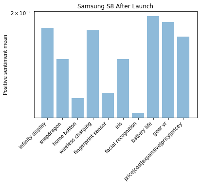

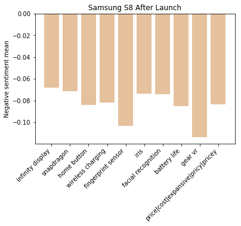

```python
x = s8_b4_launch['feature']
y = s8_b4_launch['positive_mean']
plt.bar(x, y, align='center', alpha=0.5)
plt.setp(plt.gca().get_xticklabels(), rotation=45, horizontalalignment='right')
plt.ylabel('Positive sentiment mean')
plt.title('Samsung S8 before launch')
plt.yscale('log')

plt.show()

x = s8_b4_launch['feature']
y = s8_b4_launch['negative_mean']
plt.bar(x, y, align='center', alpha=0.5, color='#CD853F')
plt.setp(plt.gca().get_xticklabels(), rotation=45, horizontalalignment='right')
plt.ylabel('Negative sentiment mean')
plt.title('Samsung S8 before launch')
# plt.yscale('log')

plt.show()


x = s8_after_launch['feature']
y = s8_after_launch['positive_mean']
plt.bar(x, y, align='center', alpha=0.5)
plt.setp(plt.gca().get_xticklabels(), rotation=45, horizontalalignment='right')
plt.ylabel('Positive sentiment mean')
plt.title('Samsung S8 After Launch')
plt.yscale('log')

plt.show()

x = s8_after_launch['feature']
y = s8_after_launch['negative_mean']
plt.bar(x, y, align='center', alpha=0.5, color='#CD853F')
plt.setp(plt.gca().get_xticklabels(), rotation=45, horizontalalignment='right')
plt.ylabel('Negative sentiment mean')
plt.title('Samsung S8 After Launch')
# plt.yscale('log')

plt.show()
```

# iPhone 8 before and after launch comparison

```python
iPDF['Published Date (GMT-04:00) New York'] = pd.to_datetime(iPDF['Published Date (GMT-04:00) New York'])
```

```python
i8_b4_launch = get_feature_df(iPDF,
                              ['oled display',
                               'snapdragon',
                               'augmented reality',
                               'wireless charging',
                               'dual camera',
                               'battery life','facial recognition',
                               'fingerprint sensor',
                               'portrait mode','price|cost|expansive|pricy|pricey'],
                              '20170822', '20170922')
```

```
Mean: 0.15772698751905787
Positive: 0.16860771899687346
Negative: -0.025964662064299652
Mean: 0.15772698751905787
Positive: 0.16860771899687346
Negative: -0.025964662064299652
Mean: 0.16576830375643714
Positive: 0.18469506807982305
Negative: -0.056598446196660476
Mean: 0.15782911277588563
Positive: 0.17360959520680636
Negative: -0.07997061712525638
Mean: 0.15389113113663108
Positive: 0.1720587163600983
Negative: -0.1129074035065692
Mean: 0.14516184942267163
Positive: 0.1616318930558479
Negative: -0.14973672321886614
Mean: 0.13506310051601922
Positive: 0.15547890208638238
Negative: -0.11192597182618191
Mean: 0.13058103189053263
Positive: 0.14643933783665553
Negative: -0.06663510927265397
Mean: 0.14847419185832164
Positive: 0.15022553994553137
Negative: -0.017903876426603706
Mean: 0.1708290118985748
Positive: 0.17930963141864625
Negative: -0.10819900702889422
Mean: 0.1454059406161002
Positive: 0.1844705294218998
Negative: -0.11503661689018117
```

```python
i8_after_launch = get_feature_df(iPDF,
                              ['oled display',
                               'snapdragon',
                               'augmented reality',
                               'wireless charging',
                               'dual camera',
                               'battery life','facial recognition',
                               'fingerprint sensor',
                               'portrait mode','price|cost|expansive|pricy|pricey'],
                              '20170922', '20171022')
```

```
Mean: 0.1447791122589309
Positive: 0.15740547418076065
Negative: -0.057396878432931286
Mean: 0.1447791122589309
Positive: 0.15740547418076065
Negative: -0.057396878432931286
Mean: 0.13807057482784396
Positive: 0.16260207872002921
Negative: -0.1193584469642911
Mean: 0.12764394167756052
Positive: 0.17742562313069937
Negative: -0.1230666542075724
Mean: 0.15127964102112085
Positive: 0.1839641634892269
Negative: -0.10558932059068589
Mean: 0.1630593471424673
Positive: 0.1908280100626893
Negative: -0.07766080108958913
Mean: 0.15262764135048584
Positive: 0.1951526302357462
Negative: -0.12792776032409847
Mean: 0.10411320442197564
Positive: 0.12414770531137827
Negative: -0.0545206579882011
Mean: 0.12832596825491355
Positive: 0.15449501019462708
Negative: -0.09436281237701694
Mean: 0.1777010726864974
Positive: 0.24402285623242473
Negative: -0.19134748729095868
Mean: 0.13865093357596367
Positive: 0.18748424629336952
Negative: -0.09746936467457902
```

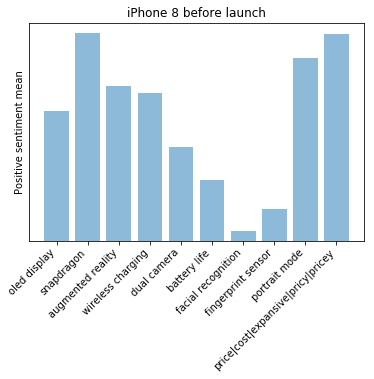

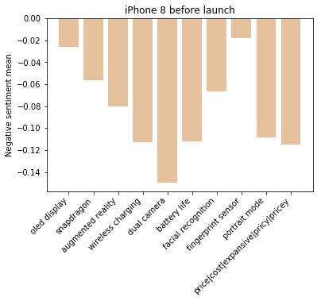

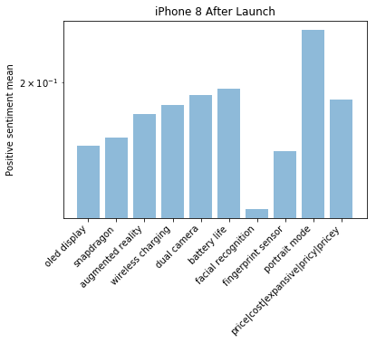

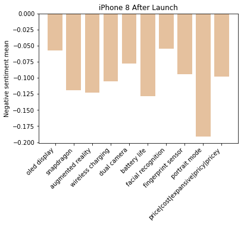

```python
x = i8_b4_launch['feature']
y = i8_b4_launch['positive_mean']
plt.bar(x, y, align='center', alpha=0.5)
plt.setp(plt.gca().get_xticklabels(), rotation=45, horizontalalignment='right')
plt.ylabel('Positive sentiment mean')
plt.title('iPhone 8 before launch')
plt.yscale('log')

plt.show()

x = i8_b4_launch['feature']
y = i8_b4_launch['negative_mean']
plt.bar(x, y, align='center', alpha=0.5, color='#CD853F')
plt.setp(plt.gca().get_xticklabels(), rotation=45, horizontalalignment='right')
plt.ylabel('Negative sentiment mean')
plt.title('iPhone 8 before launch')
# plt.yscale('log')

plt.show()


x = i8_after_launch['feature']
y = i8_after_launch['positive_mean']
plt.bar(x, y, align='center', alpha=0.5)
plt.setp(plt.gca().get_xticklabels(), rotation=45, horizontalalignment='right')
plt.ylabel('Positive sentiment mean')
plt.title('iPhone 8 After Launch')
plt.yscale('log')

plt.show()

x = i8_after_launch['feature']
y = i8_after_launch['negative_mean']
plt.bar(x, y, align='center', alpha=0.5, color='#CD853F')
plt.setp(plt.gca().get_xticklabels(), rotation=45, horizontalalignment='right')
plt.ylabel('Negative sentiment mean')
plt.title('iPhone 8 After Launch')
# plt.yscale('log')

plt.show()
```

From the graph above, we can see that before iphon8 launched, people didn't expect much on the battery life, but after launched, the response to battery life feature were positive. However, for the dual camera, people tended to have lower expectation on this feature, but after iphone 8 launched, negative response to dual camera decrease. Out of expectation, the negative reaction about portrait mode features increased.

# iPhone X before and after launch comparison

```python
iXDF = iPDF[iPDF['iX'] == 1]
```

```python
iXDF['Published Date (GMT-04:00) New York'] = pd.to_datetime(iXDF['Published Date (GMT-04:00) New York'])
```

```python
iXDF.info()
```

```
<class 'pandas.core.frame.DataFrame'>
Int64Index: 40118 entries, 103 to 380285
Data columns (total 21 columns):
index                                     40118 non-null int64
Sound Bite Text                           40118 non-null object
Title                                     40118 non-null object
Post Type                                 40118 non-null object
Published Date (GMT-04:00) New York       40118 non-null datetime64[ns]
Source Type                               40118 non-null object
No. of Followers/Daily Unique Visitors    40118 non-null float64
Author Gender                             40118 non-null object
Positive Objects                          8198 non-null object
Negative Objects                          3982 non-null object
Author Location - Country 1               40118 non-null object
lower_text                                40118 non-null object
clear_text                                40118 non-null object
clear_text_str                            40118 non-null object
blob_sentiment                            40118 non-null float64
clear_text_ngram2                         40118 non-null object
Sentiment                                 40118 non-null object
S8                                        40118 non-null float64
iPhone                                    40118 non-null float64
i8                                        40118 non-null float64
iX                                        40118 non-null float64
dtypes: datetime64[ns](1), float64(6), int64(1), object(13)
memory usage: 6.7+ MB
```

```python
iX_b4_launch = get_feature_df(iXDF,
                              ['wireless charging',
                               'face id',
                               'bionic',
                               'home button',
                               'augmented reality',
                               'dual camera','glass back',
                               'charging pad','price|cost|expansive|pricy|pricey'],
                              '20170822', '20170922')
```

```
Mean: 0.14954413586423043
Positive: 0.16433087160585552
Negative: -0.10236445950168817
Mean: 0.14954413586423043
Positive: 0.16433087160585552
Negative: -0.10236445950168817
Mean: 0.13823699687099764
Positive: 0.16124310535401123
Negative: -0.06961663197530969
Mean: 0.16032538728889567
Positive: 0.1676541980270981
Negative: -0.08897209953714519
Mean: 0.1414423289191486
Positive: 0.15149234271453316
Negative: -0.09519648559801962
Mean: 0.14353664304401448
Positive: 0.1552421773353307
Negative: -0.0725360080200974
Mean: 0.15678814937429286
Positive: 0.1625727736319085
Negative: -0.05581522034131924
Mean: 0.14444043742854232
Positive: 0.15051815713920824
Negative: -0.056819149752267546
Mean: 0.13832708506911273
Positive: 0.15492860570202593
Negative: -0.11787833072277519
Mean: 0.12976621036559663
Positive: 0.15439202048125614
Negative: -0.10368336904009864
```

```python
iX_after_launch = get_feature_df(iXDF,
                              ['wireless charging',
                               'face id',
                               'bionic',
                               'home button',
                               'augmented reality',
                               'dual camera','glass back',
                               'charging pad','price|cost|expansive|pricy|pricey'],
                               '20170922', '20171022')
```

```
Mean: 0.14002487131265864
Positive: 0.1583025782453074
Negative: -0.07125609900333636
Mean: 0.14002487131265864
Positive: 0.1583025782453074
Negative: -0.07125609900333636
Mean: 0.12175599923058175
Positive: 0.15219500400936128
Negative: -0.06419316975767732
Mean: 0.13047838187717262
Positive: 0.15783637507016507
Negative: -0.0519765309093771
Mean: 0.13573724957505406
Positive: 0.15100148244827075
Negative: -0.05792460455127567
Mean: 0.09748499783711631
Positive: 0.15645200378483407
Negative: -0.14250440176931642
Mean: 0.16152846932066625
Positive: 0.17510414876297936
Negative: -0.048894562035187036
Mean: 0.12274623767391349
Positive: 0.1364795488642416
Negative: -0.04975847702884489
Mean: 0.15640399971865943
Positive: 0.1765382610754527
Negative: -0.07620139023348169
Mean: 0.12076830238518074
Positive: 0.15009840150209344
Negative: -0.06747541803375659
```

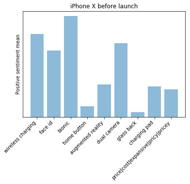

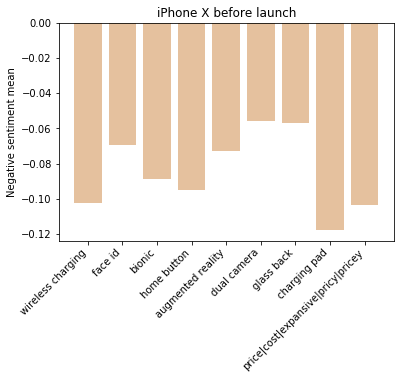

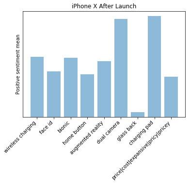

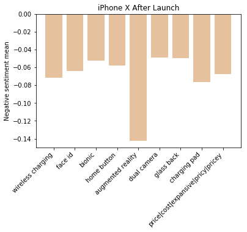

```python
x = iX_b4_launch['feature']
y = iX_b4_launch['positive_mean']
plt.bar(x, y, align='center', alpha=0.5)
plt.setp(plt.gca().get_xticklabels(), rotation=45, horizontalalignment='right')
plt.ylabel('Positive sentiment mean')
plt.title('iPhone X before launch')
plt.yscale('log')

plt.show()

x = iX_b4_launch['feature']
y = iX_b4_launch['negative_mean']
plt.bar(x, y, align='center', alpha=0.5, color='#CD853F')
plt.setp(plt.gca().get_xticklabels(), rotation=45, horizontalalignment='right')
plt.ylabel('Negative sentiment mean')
plt.title('iPhone X before launch')
# plt.yscale('log')

plt.show()


x = iX_after_launch['feature']
y = iX_after_launch['positive_mean']
plt.bar(x, y, align='center', alpha=0.5)
plt.setp(plt.gca().get_xticklabels(), rotation=45, horizontalalignment='right')
plt.ylabel('Positive sentiment mean')
plt.title('iPhone X After Launch')
plt.yscale('log')

plt.show()

x = iX_after_launch['feature']
y = iX_after_launch['negative_mean']
plt.bar(x, y, align='center', alpha=0.5, color='#CD853F')
plt.setp(plt.gca().get_xticklabels(), rotation=45, horizontalalignment='right')
plt.ylabel('Negative sentiment mean')
plt.title('iPhone X After Launch')
# plt.yscale('log')

plt.show()
```

```python
iX_b4_launch
```

|  | feature | overall_mean | positive_mean | negative_mean |
| --- | --- | --- | --- | --- |
| wireless charging | wireless charging | 0.149544 | 0.164331 | -0.102364 |
| face id | face id | 0.138237 | 0.161243 | -0.069617 |
| bionic | bionic | 0.160325 | 0.167654 | -0.088972 |
| home button | home button | 0.141442 | 0.151492 | -0.095196 |
| augmented reality | augmented reality | 0.143537 | 0.155242 | -0.072536 |
| dual camera | dual camera | 0.156788 | 0.162573 | -0.055815 |
| glass back | glass back | 0.144440 | 0.150518 | -0.056819 |
| charging pad | charging pad | 0.138327 | 0.154929 | -0.117878 |
| price\|cost\|expansive\|pricy\|pricey | price\|cost\|expansive\|pricy\|pricey | 0.129766 | 0.154392 | -0.103683 |

```python
result_iX = pd.merge(iX_b4_launch,iX_after_launch, how ="inner", on="feature")
result_iX
```

|  | feature | overall_mean_x | positive_mean_x | negative_mean_x | overall_mean_y | positive_mean_y | negative_mean_y |
| --- | --- | --- | --- | --- | --- | --- | --- |
| 0 | wireless charging | 0.149544 | 0.164331 | -0.102364 | 0.140025 | 0.158303 | -0.071256 |
| 1 | face id | 0.138237 | 0.161243 | -0.069617 | 0.121756 | 0.152195 | -0.064193 |
| 2 | bionic | 0.160325 | 0.167654 | -0.088972 | 0.130478 | 0.157836 | -0.051977 |
| 3 | home button | 0.141442 | 0.151492 | -0.095196 | 0.135737 | 0.151001 | -0.057925 |
| 4 | augmented reality | 0.143537 | 0.155242 | -0.072536 | 0.097485 | 0.156452 | -0.142504 |
| 5 | dual camera | 0.156788 | 0.162573 | -0.055815 | 0.161528 | 0.175104 | -0.048895 |
| 6 | glass back | 0.144440 | 0.150518 | -0.056819 | 0.122746 | 0.136480 | -0.049758 |
| 7 | charging pad | 0.138327 | 0.154929 | -0.117878 | 0.156404 | 0.176538 | -0.076201 |
| 8 | price\|cost\|expansive\|pricy\|pricey | 0.129766 | 0.154392 | -0.103683 | 0.120768 | 0.150098 | -0.067475 |

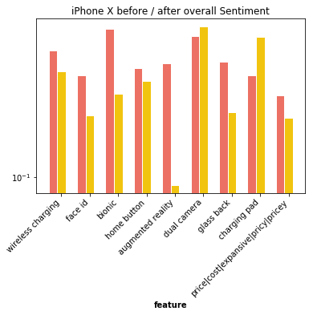

```python
iX_f = result_iX['feature']
iX_b4o = result_iX['overall_mean_x']
iX_afo = result_iX['overall_mean_y']

barWidth = 0.3

r1 = np.arange(len(iX_f))
r2 = [x + barWidth for x in r1]
plt.bar(r1,iX_b4o, color='#EC7063', width=barWidth, edgecolor='white', label='b4')
plt.bar(r2,iX_afo, color='#F1C40F', width=barWidth, edgecolor='white', label='af')
plt.xlabel('feature', fontweight='bold')
plt.xticks([r + barWidth for r in range(len(iX_f))], result_iX['feature'].values)
plt.setp(plt.gca().get_xticklabels(), rotation=45, horizontalalignment='right')
plt.yscale('log')
plt.title('iPhone X before / after overall Sentiment')
plt.show()
```

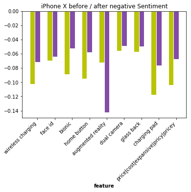

```python
iX_f = result_iX['feature']
iX_b4o = result_iX['negative_mean_x']
iX_afo = result_iX['negative_mean_y']

barWidth = 0.3

r1 = np.arange(len(iX_f))
r2 = [x + barWidth for x in r1]
plt.bar(r1,iX_b4o, color='#b9c406', width=barWidth, edgecolor='white', label='b4')
plt.bar(r2,iX_afo, color='#824ca7', width=barWidth, edgecolor='white', label='af')
plt.xlabel('feature', fontweight='bold')
plt.xticks([r + barWidth for r in range(len(iX_f))], result_iX['feature'].values)
plt.setp(plt.gca().get_xticklabels(), rotation=45, horizontalalignment='right')
plt.title('iPhone X before / after negative Sentiment')
# plt.yscale('log')
plt.show()
```

Before iphone X launched, people had some concerns about augmented reality, so it showed some negative reaction on this feature. After launched, we can see from the data that people truly didn't buy-in the augmented reality feature which become the most dislike feature for iphone X.